# Optimization for machine learning

Joshua Loftus

# 1-d smooth regression example

## Example data

Generate a one-dimensional example with a non-linear relationship

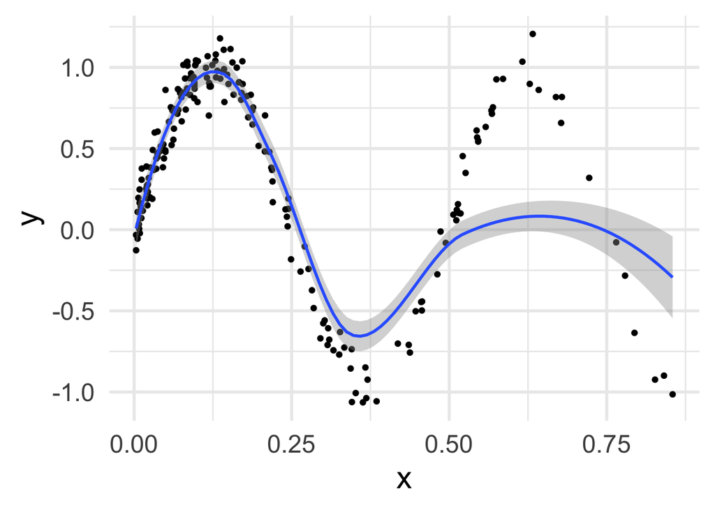

```r
# change this function
f <- function(x) sin(4*pi*x)
n <- 200
train1d <-
  data.frame(
    x = rbeta(n, 1, 3)
    ) %>%
  # change the noise level sd
  mutate(y = f(x) + rnorm(n, sd = .1))

# plot data and loess curve
ggplot(train1d, aes(x, y)) +
  geom_point() +
  geom_smooth()
```

Linear regression with a polynomial transform of x

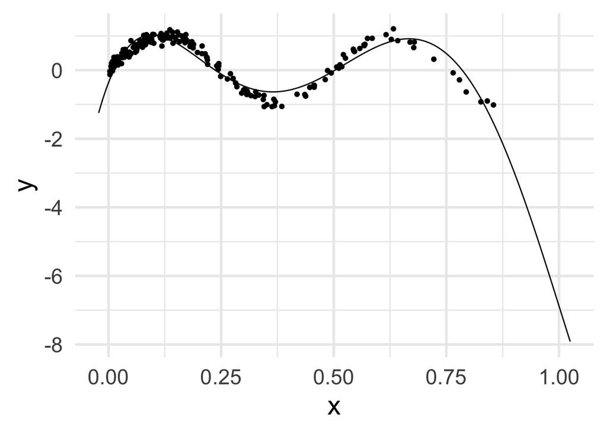

```r
model_lm <- lm(y ~ poly(x, 5), data = train1d)

train1d_grid <-
  data_grid(train1d,
          x = seq_range(c(x, 1), 500, expand = .05))

augment(model_lm,
        newdata = train1d_grid) %>%
  ggplot(aes(x, y)) +
  geom_point(data = train1d) +
  geom_line(aes(y = .fitted))
```

## Gradient descent

Goal: implement gradient descent and use it to solve for the coefficients of the above linear model

Hint: `model.matrix(model_lm)` can give you the predictor matrix

### Step 1: write functions to output the least squares loss and its gradient

### Step 2: write a loop to take multiple steps in the direction of the negative gradient, keeping step size fixed

### Step 3: write a function to step in the direction of the negative gradient until the loss function no longer decreases by a certain amount, keeping step size fixed

### Step 4: experiment with manually decreasing the stepsize and convergence threshold

### Step 5: use the Barzilai-Borwein method to choose step size

See https://en.wikipedia.org/wiki/Gradient_descent

# Classification example

## Generate data

Which predictors have nonzero coefficients?

```r
n <- 100; p <- 4; sparsity <- 2
x <- matrix(rnorm(n*p), nrow = n)
true_beta <- c(rep(1, sparsity), rep(0, p - sparsity))
mu <- x %*% true_beta
px <- exp(mu)/(1+exp(mu))
y <- rbinom(n, 1, px)
train_hd <- data.frame(y = as.factor(y), x = x)
```

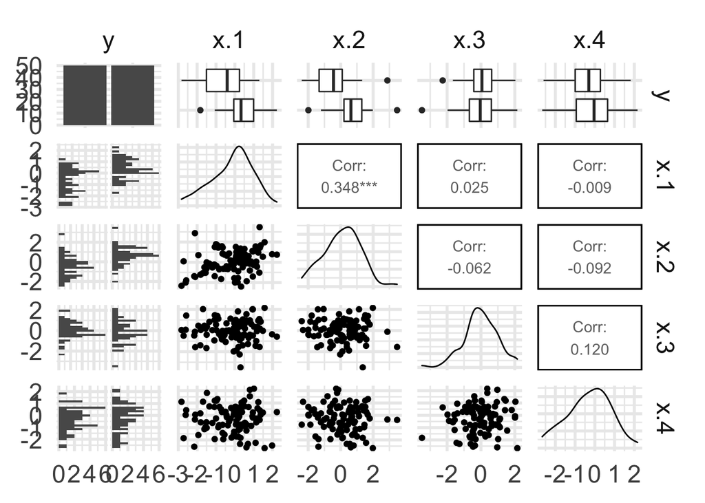

```r
train_hd %>%
  select(y, num_range("x.", 1:4)) %>%
  ggpairs(progress = F)
```

## Implement gradient descent

First try this with logistic loss function

### Step 1: use numerical differential to approximate gradient

(see references below)

### Step 5: full implementation

### Check answer with results from `glm` (if possible, when p < n)

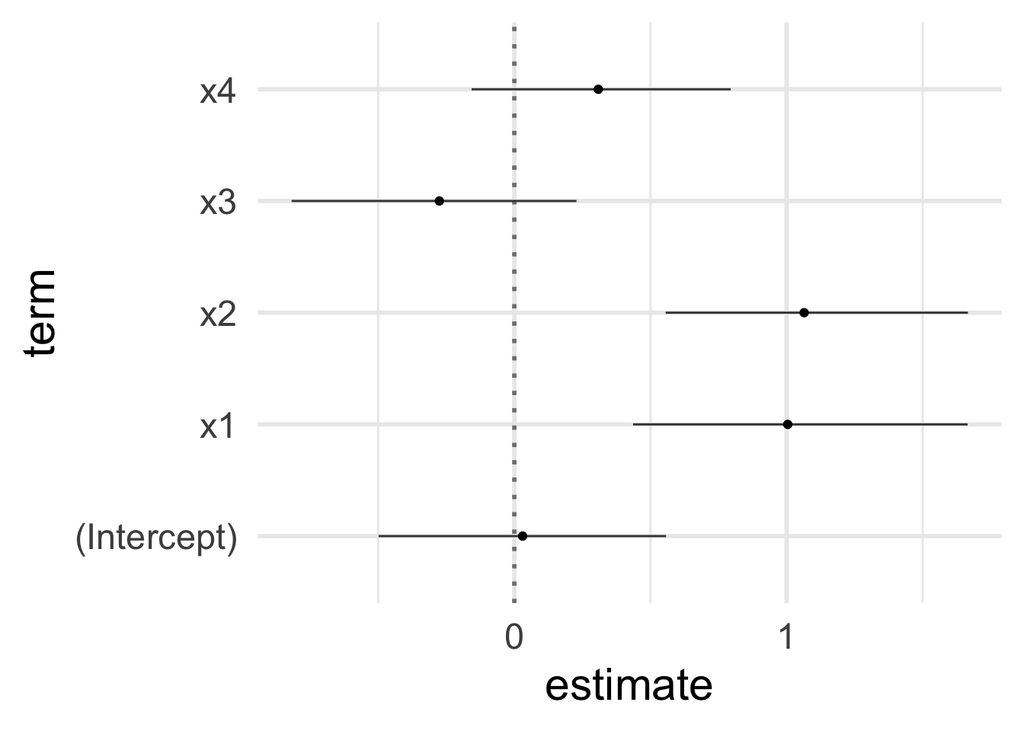

```r
glm(y ~ x, family = "binomial") %>%
  ggcoef()
```

# High dimensional regression and SGD

## Generate data

```r
n <- 100; p <- 200; sparsity <- 3
x <- matrix(rnorm(n*p), nrow = n)
true_beta <- c(rep(1, sparsity), rep(0, p - sparsity))
y <- x %*% true_beta
train_hd <- data.frame(y = y, x = x)
```

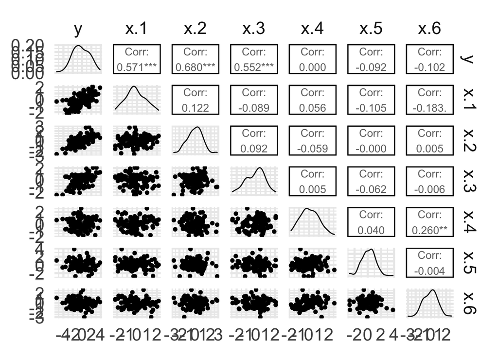

```r
train_hd %>%
  select(y, num_range("x.", 1:6)) %>%
  ggpairs(progress = F)
```

## Implement SGD for least squares

See the references for hints

Question: does it converge? There is no unique solution for least squares in high dimensional regression.

# Extra practice

- Modify the least squares loss function by adding a penalty on the coefficients, e.g. loss = MSE + L*beta^2, where L is a non-negative constant. Compute the new gradient and implement SGD with this loss function. Try various values of L on the same dataset, and implement “tuning” to find the best value of L
- Implement SGD for logistic and hinge loss functions, and try it out on some examples of data that you generate where you know the true answer

# References

- https://mlstory.org/optimization.html for gradient descent, stochastic gradient descent, SGD quick start guide
- https://en.wikipedia.org/wiki/Numerical_differentiation for symmetric difference quotient, step size
- Type `.Machine` in the console and look for `double.eps`